## **Programming**

### For someone who has never learned a computer language completely, it sure seems like I’ve written a lot of code in my life. I remember bits of Basic, GWBasic, QuickBasic, VisualBasic, Java, Python, EasyLanguage(finance), STATA, and some assembly language too — always changing. Recently I’ve tried to focus on R. I can learn any language you need though.

### This HTML document was built using Rmarkdown from within RStudio. This is great for statistical reporting and ensuring repeatability. Dynamic code right in the document is the key. The following content is just for illustration.

### **Look at the “cars” data set that is built into R**

```r
str(cars) # this function shows the structure of cars
```

```
## 'data.frame':    50 obs. of  2 variables:
##  $ speed: num  4 4 7 7 8 9 10 10 10 11 ...
##  $ dist : num  2 10 4 22 16 10 18 26 34 17 ...
```

With Rmarkdown we can explain as we go. We just took a look at the structure of the cars data output by the str() function. Now let’s look at boxplots.

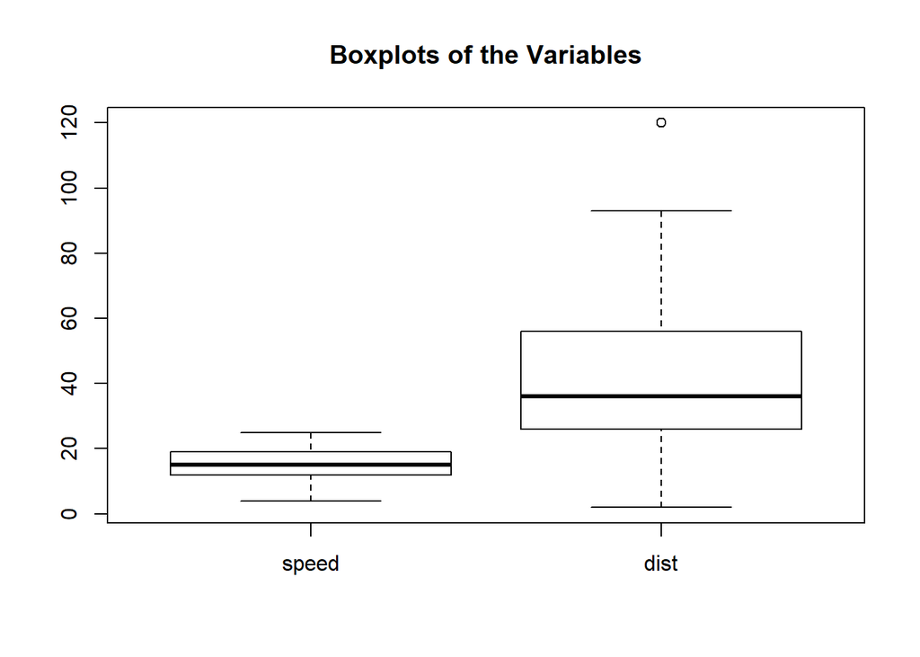

```r
boxplot(cars)
title("Boxplots of the Variables")
```

### **Now fit a linear model on speed and distance using lm()**

```r
mymod <- lm(cars$dist ~ cars$speed)
summary(mymod)
```

```
##
## Call:
## lm(formula = cars$dist ~ cars$speed)
##
## Residuals:
##     Min      1Q  Median      3Q     Max
## -29.069  -9.525  -2.272   9.215  43.201
##
## Coefficients:
##             Estimate Std. Error t value Pr(>|t|)
## (Intercept) -17.5791     6.7584  -2.601   0.0123 *
## cars$speed    3.9324     0.4155   9.464 1.49e-12 ***
## ---
## Signif. codes:  0 '***' 0.001 '**' 0.01 '*' 0.05 '.' 0.1 ' ' 1
##
## Residual standard error: 15.38 on 48 degrees of freedom
## Multiple R-squared:  0.6511, Adjusted R-squared:  0.6438
## F-statistic: 89.57 on 1 and 48 DF,  p-value: 1.49e-12
```

Looks like the relationship can be described with a factor of 3.9 or so. Now instead of using R’s lm() function I’ll go through the model with manual matrix operations.

### **Try doing the same thing from scratch with linear algebra**

```r
Y <- as.matrix(cars$dist) # dependent variable put in Y
X <- as.matrix(cars$speed) # independent variable put in X
X <- cbind(x0=rep(1, nrow(X)), X) # add a buncha ones to the matrix X
Xt <- t(X) # transform of X
XtXinverse <- solve(Xt %*% X) # use solve() to get the inverse of Xt•X
XtXinverseXt <- XtXinverse %*% Xt # multiply by Xt again
XtXinverseXtY <- XtXinverseXt %*% Y # multiply by Y

XtXinverseXtY
```

```
##          [,1]
## x0 -17.579095
##      3.932409
```

We still get about 3.9 for a linear description of the relationship. Pretty cool!

### **Pictures, animations, and other fun stuff can be inserted. Here is a formula for example.**

$$\sqrt{\bar{x}}=(X/n)^.5$$